# Ford GoBike System Data Exploration

## by: Ahmed Magdy Abdelhaseib Mohamed

- Univariate Exploration
- Bivaraite Exploration
- Multivariate Exploration

## Preliminary Wrangling

This document explores a dataset includes information about individual rides made in a bike-sharing system covering the greater San Francisco Bay area.

```python
# import all packages and set plots to be embedded inline
import numpy as np
import pandas as pd
import matplotlib.pyplot as plt
import seaborn as sb

%matplotlib inline
```

### Gathering the data

```python
df = pd.read_csv('bike-data.csv')
df.head()
```

|  | duration_sec | start_time | end_time | start_station_id | start_station_name | start_station_latitude | start_station_longitude | end_station_id | end_station_name | end_station_latitude | end_station_longitude | bike_id | user_type | member_birth_year | member_gender | bike_share_for_all_trip |
| --- | --- | --- | --- | --- | --- | --- | --- | --- | --- | --- | --- | --- | --- | --- | --- | --- |
| 0 | 52185 | 2019-02-28 17:32:10.1450 | 2019-03-01 08:01:55.9750 | 21.0 | Montgomery St BART Station (Market St at 2nd St) | 37.789625 | -122.400811 | 13.0 | Commercial St at Montgomery St | 37.794231 | -122.402923 | 4902 | Customer | 1984.0 | Male | No |
| 1 | 42521 | 2019-02-28 18:53:21.7890 | 2019-03-01 06:42:03.0560 | 23.0 | The Embarcadero at Steuart St | 37.791464 | -122.391034 | 81.0 | Berry St at 4th St | 37.775880 | -122.393170 | 2535 | Customer | NaN | NaN | No |
| 2 | 61854 | 2019-02-28 12:13:13.2180 | 2019-03-01 05:24:08.1460 | 86.0 | Market St at Dolores St | 37.769305 | -122.426826 | 3.0 | Powell St BART Station (Market St at 4th St) | 37.786375 | -122.404904 | 5905 | Customer | 1972.0 | Male | No |
| 3 | 36490 | 2019-02-28 17:54:26.0100 | 2019-03-01 04:02:36.8420 | 375.0 | Grove St at Masonic Ave | 37.774836 | -122.446546 | 70.0 | Central Ave at Fell St | 37.773311 | -122.444293 | 6638 | Subscriber | 1989.0 | Other | No |
| 4 | 1585 | 2019-02-28 23:54:18.5490 | 2019-03-01 00:20:44.0740 | 7.0 | Frank H Ogawa Plaza | 37.804562 | -122.271738 | 222.0 | 10th Ave at E 15th St | 37.792714 | -122.248780 | 4898 | Subscriber | 1974.0 | Male | Yes |

### Assessing the data

```python
df.shape
```

```
(183412, 16)
```

```python
df.info()
```

```
<class 'pandas.core.frame.DataFrame'>
RangeIndex: 183412 entries, 0 to 183411
Data columns (total 16 columns):
 #   Column                   Non-Null Count   Dtype
---  ------                   --------------   -----
 0   duration_sec             183412 non-null  int64
 1   start_time               183412 non-null  object
 2   end_time                 183412 non-null  object
 3   start_station_id         183215 non-null  float64
 4   start_station_name       183215 non-null  object
 5   start_station_latitude   183412 non-null  float64
 6   start_station_longitude  183412 non-null  float64
 7   end_station_id           183215 non-null  float64
 8   end_station_name         183215 non-null  object
 9   end_station_latitude     183412 non-null  float64
 10  end_station_longitude    183412 non-null  float64
 11  bike_id                  183412 non-null  int64
 12  user_type                183412 non-null  object
 13  member_birth_year        175147 non-null  float64
 14  member_gender            175147 non-null  object
 15  bike_share_for_all_trip  183412 non-null  object
dtypes: float64(7), int64(2), object(7)
memory usage: 22.4+ MB
```

```python
df.isnull().sum()
```

```
duration_sec                  0
start_time                    0
end_time                      0
start_station_id            197
start_station_name          197
start_station_latitude        0
start_station_longitude       0
end_station_id              197
end_station_name            197
end_station_latitude          0
end_station_longitude         0
bike_id                       0
user_type                     0
member_birth_year          8265
member_gender              8265
bike_share_for_all_trip       0
dtype: int64
```

```python
# calculating the Distance Between each Two stations using its coordinates (longitudes & latitudes)
lat1 = df['start_station_latitude'].apply(lambda x:np.radians(x))
lat2 = df['end_station_latitude'].apply(lambda x:np.radians(x))
lon1 = df['start_station_longitude'].apply(lambda x:np.radians(x))
lon2 = df['end_station_longitude'].apply(lambda x:np.radians(x))

# Haversine formula
dlon = lon2 - lon1
dlat = lat2 - lat1
a = dlat.apply(lambda x:np.sin(x/2)**2) + lat1.apply(lambda x:np.cos(x)) \
        * lat2.apply(lambda x:np.cos(x)) * dlon.apply(lambda x:np.sin(x/2)**2)

c = a.apply(lambda x: 2 * np.arcsin(np.sqrt(x)))

# Radius of earth in meter. Use 6371 for km
r = 6371

# calculate the result
df['distance_Km'] = c.apply(lambda x: r * x)
```

```python
df[df['distance_Km'] == 0].shape
```

```
(3880, 17)
```

```python
df.duplicated().sum()
```

```
0
```

```python
df[df['member_birth_year'] < 1950].shape
```

```
(674, 17)
```

### Cleaning the data

```python
df_clean = df.copy()
```

```python
# Drop the missing values
df_clean.dropna(inplace=True)
```

```python
# fixing the features data types
df_clean['start_time'] = pd.to_datetime(df_clean['start_time'])
df_clean['end_time'] = pd.to_datetime(df_clean['end_time'])
df_clean['member_birth_year'] = df_clean['member_birth_year'].astype(int)
df_clean['start_station_id'] = df_clean['start_station_id'].astype(str)
df_clean['end_station_id'] = df_clean['end_station_id'].astype(str)
df_clean['bike_id'] = df_clean['bike_id'].astype(str)
```

```python
# I will drop all values with 0 distance
df_clean.drop(index=df_clean.loc[(df_clean['distance_Km'] == 0),:].index, inplace=True)
```

```python
# I want to make sure that all values in columns 'duration_sec' equal the difference
# between the end time and the start time
df_clean['duration_sec'] = (df_clean['end_time'] - df_clean['start_time']).apply(lambda x: int(x.total_seconds()))
```

```python
# I will drop all values that less than 1950
df_clean.drop(index=df_clean.loc[(df_clean['member_birth_year'] < 1950),:].index, inplace=True)
```

```python
# adding new variabel day of the week
df_clean['day_of_week'] = df_clean['start_time'].dt.day_name()

days = ['Monday', 'Thursday', 'Wednesday', 'Tuesday', 'Friday', 'Saturday', 'Sunday']
days = pd.api.types.CategoricalDtype(ordered=True, categories=days)
df_clean['day_of_week'] = df_clean['day_of_week'].astype(days)
```

### Testing

```python
df_clean.isnull().sum()
```

```
duration_sec               0
start_time                 0
end_time                   0
start_station_id           0
start_station_name         0
start_station_latitude     0
start_station_longitude    0
end_station_id             0
end_station_name           0
end_station_latitude       0
end_station_longitude      0
bike_id                    0
user_type                  0
member_birth_year          0
member_gender              0
bike_share_for_all_trip    0
distance_Km                0
day_of_week                0
dtype: int64
```

```python
df_clean.dtypes
```

```
duration_sec                        int64
start_time                 datetime64[ns]
end_time                   datetime64[ns]
start_station_id                   object
start_station_name                 object
start_station_latitude            float64
start_station_longitude           float64
end_station_id                     object
end_station_name                   object
end_station_latitude              float64
end_station_longitude             float64
bike_id                            object
user_type                          object
member_birth_year                   int32
member_gender                      object
bike_share_for_all_trip            object
distance_Km                       float64
day_of_week                      category
dtype: object
```

```python
df_clean[df_clean['distance_Km'] == 0]
```

|  | duration_sec | start_time | end_time | start_station_id | start_station_name | start_station_latitude | start_station_longitude | end_station_id | end_station_name | end_station_latitude | end_station_longitude | bike_id | user_type | member_birth_year | member_gender | bike_share_for_all_trip | distance_Km | day_of_week |
| --- | --- | --- | --- | --- | --- | --- | --- | --- | --- | --- | --- | --- | --- | --- | --- | --- | --- | --- |

### What is the structure of your dataset?

> There are 170839 trips in this dataset with 18 features('duration_sec', 'start_time', 'end_time', 'start_station_id', 'start_station_name', 'start_station_latitude','start_station_longitude', 'end_station_id', 'end_station_name', 'end_station_latitude', 'end_station_longitude', 'bike_id', 'user_type','member_birth_year', 'member_gender', 'bike_share_for_all_trip','distance_Km', 'day_of_week') these trips happened in the period between febreuary and march in 2019.
> - Features ('duration_sec', 'start_station_latitude','start_station_longitude', 'end_station_latitude', 'end_station_longitude') are numeric
> - Features (start_time', 'end_time') are datatime
> - all the other features are categorical features.

### What is/are the main feature(s) of interest in your dataset?

> I am most interested in figuring out what features are best for predicting the duration of the trips in the dataset.

### What features in the dataset do you think will help support your investigation into your feature(s) of interest?

> I expect that distance will have the strongest effect on each trip's duration: the longer the distance, the longer the duration. I also think that the other user's infromation: user_type, member_birth_year, and member_gender, day_of_week, will have effects on the duration, though to a much smaller degree than the main effect of the distance.

## Univariate Exploration

```python
df_clean.describe()
```

|  | duration_sec | start_station_latitude | start_station_longitude | end_station_latitude | end_station_longitude | member_birth_year | distance_Km |
| --- | --- | --- | --- | --- | --- | --- | --- |
| count | 170839.000000 | 170839.000000 | 170839.000000 | 170839.000000 | 170839.000000 | 170839.000000 | 170839.000000 |
| mean | 682.438302 | 37.771466 | -122.352265 | 37.771666 | -122.351832 | 1984.982258 | 1.724848 |
| std | 1536.702344 | 0.099639 | 0.116994 | 0.099540 | 0.116546 | 9.643024 | 1.080548 |
| min | 61.000000 | 37.317298 | -122.453704 | 37.317298 | -122.453704 | 1950.000000 | 0.013287 |
| 25% | 323.000000 | 37.770407 | -122.411901 | 37.770407 | -122.411647 | 1980.000000 | 0.939302 |
| 50% | 508.000000 | 37.780760 | -122.398279 | 37.781010 | -122.397437 | 1987.000000 | 1.456572 |
| 75% | 779.000000 | 37.797320 | -122.283127 | 37.797320 | -122.287610 | 1992.000000 | 2.249416 |
| max | 84548.000000 | 37.880222 | -121.874119 | 37.880222 | -121.874119 | 2001.000000 | 69.469241 |

I will start by looking at the distribution of the main variable of interest Duration

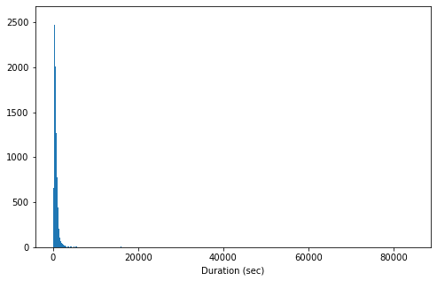

```python
# start with a standard-scaled plot
plt.figure(figsize=(8, 5))
bins = np.arange(0, 84548+10, 10)
plt.hist(data=df_clean, x='duration_sec', bins=bins)
plt.xlabel('Duration (sec)');
```

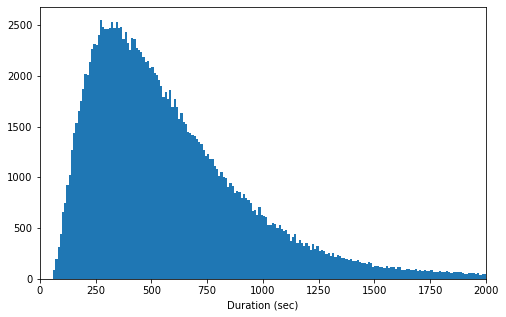

```python
# taking limits for x-axis to get a deeper look
plt.figure(figsize=(8, 5))
bins = np.arange(0, 2000+10, 10)
plt.hist(data=df_clean, x='duration_sec', bins=bins)
plt.xlim([0, 2000])
plt.xlabel('Duration (sec)');
```

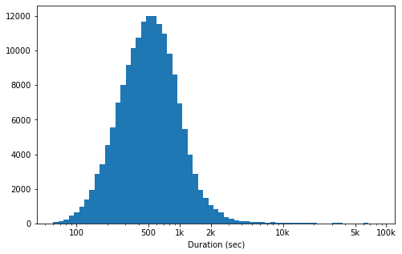

```python
# The data is concentrated in a specific region and it seems that there is a tail of it
#, so let's put it on a log scale instead to get a deeper look
log_binsize = 0.05
bins =10** np.arange(np.log10(60), np.log10(84548)+log_binsize, log_binsize)

plt.figure(figsize=(8, 5))
plt.hist(data=df_clean, x='duration_sec', bins=bins)
plt.xscale('log')
plt.xticks([100, 500, 1e3, 2e3, 5e4, 1e4, 1e5], [100, 500, '1k', '2k', '5k', '10k', '100k'])
plt.xlabel('Duration (sec)');
```

Duration has a long tail distribution, with most of the trips have low durationsand only few trips have high durations. when plotted on log-scale the distribution of the duration looks unimodal and its peak at 500 seconds. There are some outliers for points greater than 10k seconds.

Next up the first predictor variable of interest: distance

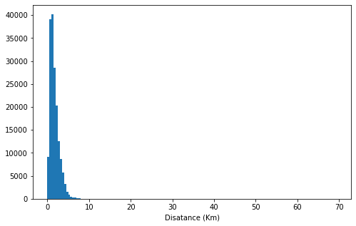

```python
# start with a standard-scaled plot
plt.figure(figsize=(8, 5))
binsize = 0.5
bins = np.arange(0, df.distance_Km.max()+binsize, binsize)
plt.hist(data=df_clean, x='distance_Km', bins=bins)
plt.xlabel('Disatance (Km)');
```

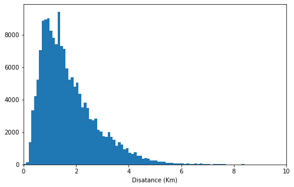

```python
# taking limits for x-axis to get a deeper look
plt.figure(figsize=(8, 5))
bins = np.arange(0, 10+0.1, 0.1)
plt.hist(data=df_clean, x='distance_Km', bins=bins)
plt.xlim([0, 10])
plt.xlabel('Disatance (Km)');
```

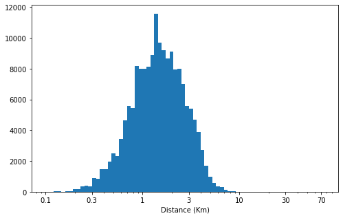

```python
# The data is concentrated in a specific region and it seems that there is a tail of it
#, so let's put it on a log scale instead to get a deeper look
log_binsize = 0.04
bins =10** np.arange(-1, np.log10(70)+log_binsize, log_binsize)

plt.figure(figsize=(8, 5))
plt.hist(data=df_clean, x='distance_Km', bins=bins)
plt.xscale('log')
plt.xticks([0.1, 0.3, 1, 3, 10, 30, 70], [0.1, 0.3, 1, 3, 10, 30, 70])
plt.xlabel('Distance (Km)');
```

In the case of distance, the first plot shows that most of the points lie in the low distances and by taking a small bin size in the second plot we discover that the distribution has a long tail and most of the trips lie between 0 to 4 km. the third plot was plotted on log-scale to show the distribution tail clearly, the distribution is unimodal and its peak is below 2 km.

I'll now move on to the other variables in the dataset: user_type, memeber_gender, member_birth_year, day_of_week.

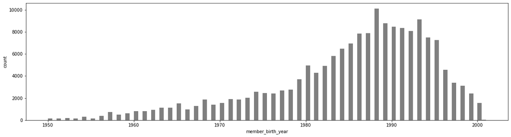

```python
# the distribution of the member bith year
bins = np.arange(1950, 2001+0.5, 0.5)
plt.figure(figsize=(20, 5))
base_color = sb.color_palette()[7]
plt.hist(data=df_clean, x='member_birth_year', bins=bins, color=base_color, alpha=1)
plt.xlabel('member_birth_year')
plt.ylabel('count');
```

By looking at the 'member_birth-year' we find that most of the riders were born in eighties or nineties and a few of them were born fifties, sixties and seventies.

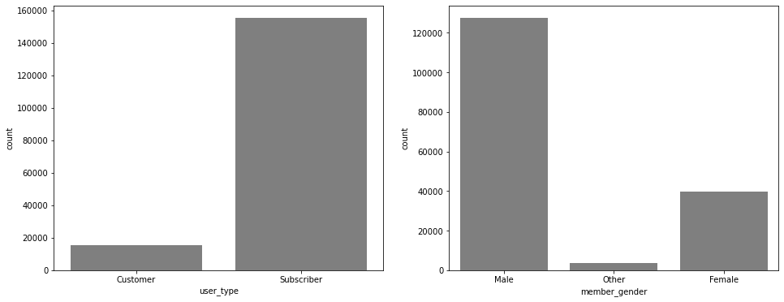

```python
# plotting the two categorical variable user_type & member_gender
fig, ax = plt.subplots(ncols=2, figsize = [16,6])
sb.countplot(data=df_clean, x='user_type', color=base_color, ax=ax[0])
sb.countplot(data=df_clean, x='member_gender', color=base_color, ax=ax[1]);
```

- In the user type plot the number of subscribers is much biger than the number of customers.
- In the member gender plot we find that the number of males is the largest and number of females come in the second order and the number of others is the lowest.

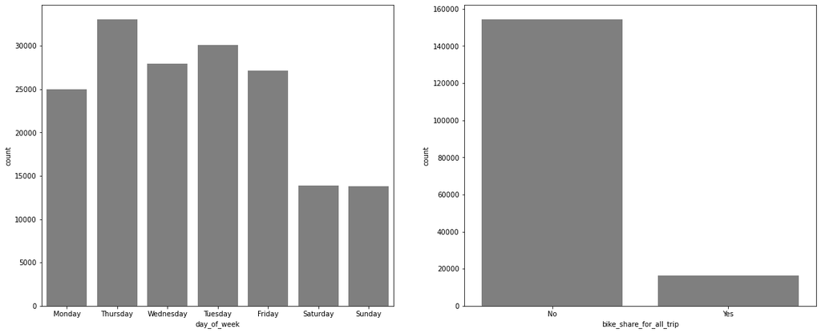

```python
# plotting the two categorical variable day_of_week & bike_share_for_all_trip
plt.figure(figsize=(20, 8))
plt.subplot(1, 2, 1)
sb.countplot(data=df_clean, x='day_of_week', color=base_color, alpha=1)
plt.subplot(1, 2, 2)
sb.countplot(data=df_clean, x='bike_share_for_all_trip', color=base_color, alpha=1);
```

- It is clear that the lowest number of trips is in the weekend while in other days it is larger. Thursday is the most crowded day and Tuesday come in the second order.
- The number of shared bikes is very lower than that were not shared

### Discuss the distribution(s) of your variable(s) of interest. Were there any unusual points? Did you need to perform any transformations?

> Duration has a long tail distribution, with most of the trips have low durations, only few trips have high durations. when plotted on log-scale the distribution of the duration looked unimodal and its peak at 500 seconds. There is some outliers for points greater than 10k seconds.

### Of the features you investigated, were there any unusual distributions? Did you perform any operations on the data to tidy, adjust, or change the form of the data? If so, why did you do this?

> when i investigated the 'member_birth_year' variable i found some illogical values like (1878, 1910, 1920,....etc) so, i took 1950 as the minimum year for my exploration and i droped the other observations which are 674 observation.

## Bivariate Exploration

To start off with, I want to look at the pairwise correlations present between features in the data.

```python
numeric_vars = ['duration_sec', 'distance_Km', 'member_birth_year']
categorical_vars = ['user_type', 'member_gender', 'day_of_week', 'bike_share_for_all_trip']
```

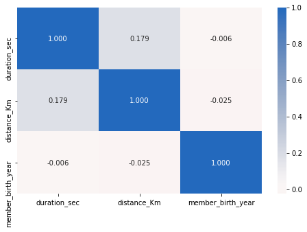

```python
# correlation plot
plt.figure(figsize=(8, 5))
sb.heatmap(df_clean[numeric_vars].corr(), annot=True, fmt='.3f', cmap="vlag_r", center=0);
```

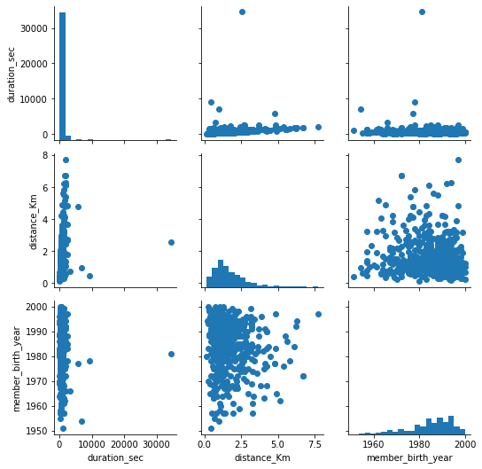

```python
# plot matrix: sample 500 diamonds so that plots are clearer and
# they render faster
sample = np.random.choice(df_clean.shape[0], 500, replace=False)
df_sample = df_clean.iloc[sample,:]
g = sb.PairGrid(data = df_sample, vars = numeric_vars)
g = g.map_diag(plt.hist, bins = 20);
g.map_offdiag(plt.scatter);
```

As not expected there is a weak positive correlation between the duration and distance variables and the 'member birth year' doesn't have a strong effect on the duration variable. This will be worth investigating more later on, using the full data.

Let's move on to looking at how duration and distance correlate with the categorical variables.

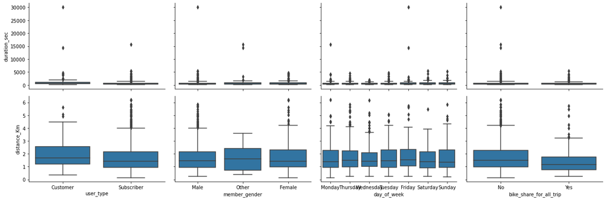

```python
# plot matrix of numeric features against categorical features
sample = np.random.choice(df_clean.shape[0], 2000, replace = False)
df_samp = df_clean.iloc[sample,:]
def box_grid(x, y, **kwargs):
    """ Quick hack for creating box plots with seaborn's PairGrid. """
    default_color = sb.color_palette()[0]
    sb.boxplot(x, y, color=default_color)

plt.figure(figsize=(20, 20))
g = sb.PairGrid(data=df_samp, y_vars=['duration_sec', 'distance_Km'], x_vars=categorical_vars, size=3, aspect=1.5)
g.map(box_grid);
```

duration and distance variables have a long scale of values and most of the points have low values so plotting these variables withount transforming its scale if not effective so, we will investigate them again later on by taking the log-transformation for them and look at thier correlation with each other and with other variables.

Finally, let's look at relationships between the four categorical features.

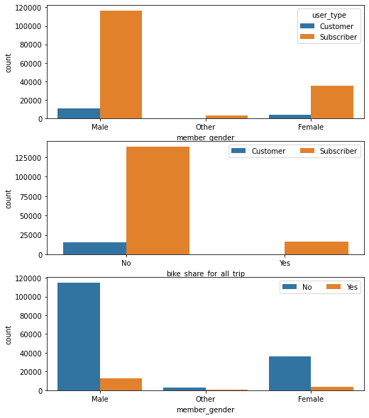

```python
# since there's only three subplots to create, using the full data should be fine.
plt.figure(figsize = [8, 10])

# subplot 1: user_type vs member_gender
plt.subplot(3, 1, 1)
sb.countplot(data = df_clean, x = 'member_gender', hue = 'user_type')

# subplot 2: bike_share_for_all_trip vs. user_type
ax = plt.subplot(3, 1, 2)
sb.countplot(data = df_clean, x = 'bike_share_for_all_trip', hue = 'user_type')
ax.legend(ncol = 2) # re-arrange legend to reduce overlapping

# subplot 3: member_gender vs. bike_share_for_all_trip
ax = plt.subplot(3, 1, 3)
sb.countplot(data = df_clean, x = 'member_gender', hue = 'bike_share_for_all_trip')
ax.legend(loc = 1, ncol = 2); # re-arrange legend to remove overlapping
```

This relation between these categorical variable was expected. Male, No and Subscriber, these values are represented in the data more than the other values. but what is new here is that all riders that thier gender is other or they shared thier bikes are Subscriber.

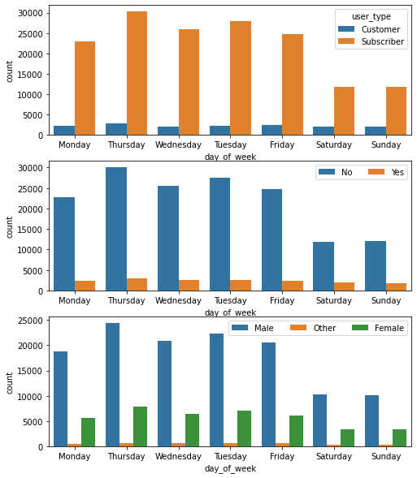

```python
plt.figure(figsize = [8, 10])

# subplot 1: day_of_week vs user_type
plt.subplot(3, 1, 1)
sb.countplot(data = df_clean, x = 'day_of_week', hue = 'user_type')

# subplot 2: bike_share_for_all_trip vs. 'day_of_week'
ax = plt.subplot(3, 1, 2)
sb.countplot(data = df_clean, x ='day_of_week' , hue = 'bike_share_for_all_trip')
ax.legend(ncol = 2) # re-arrange legend to reduce overlapping

# subplot 3: member_gender vs.'day_of_week'
ax = plt.subplot(3, 1, 3)
sb.countplot(data = df_clean, x = 'day_of_week', hue = 'member_gender')
ax.legend(loc = 1, ncol = 3); # re-arrange legend to remove overlapping
```

There is no any interaction between these categorical variable

With the preliminary look at bivariate relationships out of the way, I want to dig into some of the relationships more. First, I want to see how duration and distance are related to one another for all of the data, and to plot duration on a log scale.

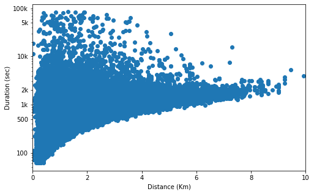

```python
plt.figure(figsize=(8,5))
plt.scatter(data=df_clean, x='distance_Km', y='duration_sec')
plt.yscale('log')
plt.xlim([0, 10])
plt.yticks([100, 500, 1e3, 2e3, 5e4, 1e4, 1e5], [100, 500, '1k', '2k', '5k', '10k', '100k'])
plt.xlabel('Distance (Km)')
plt.ylabel('Duration (sec)');
```

This plot suggests from the concavity that we might want to also transform the 'distance' variable to see a better trend.

```python
# creat a log transformation colums for duration and distance
def log_trans(x, inverse=False):
    """ quick function for computing log and power operations """
    if not inverse:
        return np.log10(x)
    else:
        return np.power(10, x)


df_clean['log_duration'] = df_clean['duration_sec'].apply(log_trans)
df_clean['log_distance'] = df_clean['distance_Km'].apply(log_trans)
```

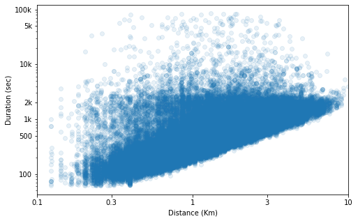

```python
# plott duration vs distance but on log-scale
plt.figure(figsize=(8,5))
plt.scatter(data=df_clean, x='log_distance', y='duration_sec', alpha=1/10)
plt.yscale('log')
plt.xlim([log_trans(.1), log_trans(10)])
plt.yticks([100, 500, 1e3, 2e3, 5e4, 1e4, 1e5], [100, 500, '1k', '2k', '5k', '10k', '100k'])
plt.xticks(log_trans(np.array([0.1, 0.3, 1, 3, 10])), [0.1, 0.3, 1, 3, 10])
plt.xlabel('Distance (Km)')
plt.ylabel('Duration (sec)');
```

Now we get a better looke, we can see here that there is a strong positive correlation between the duration and distance variable when they were plotted in the log-scale. when we take limits to x-axis to looke deeperly to the crowded region, we can see that the cloud of points is close to the bottom right than the upper life which means that the variation on the duration axis is smaller than the distance axis.

Now lets take a second look at the relationship between duration & distance on log scale and the other categorical variables.

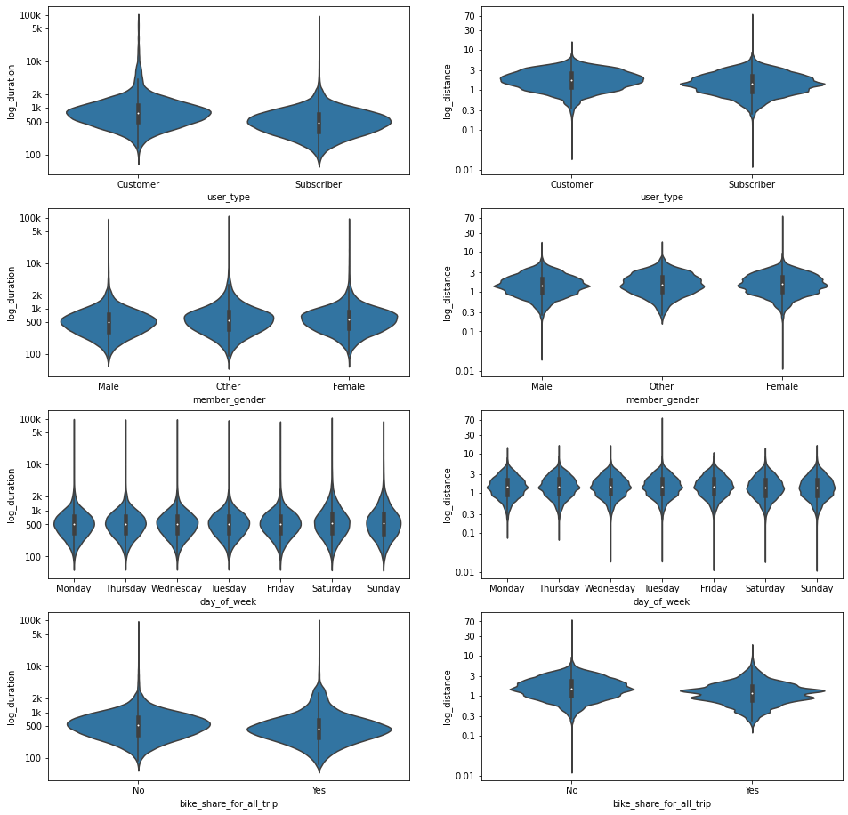

```python
# plot the categorical variables against duration and distance again, this time
# with full data and variable transforms
default_color = sb.color_palette()[0]
fig, ax = plt.subplots(nrows=4, ncols=2, figsize=(16, 16))
for i in range(len(categorical_vars)):
    var = categorical_vars[i]
    sb.violinplot(data=df_clean, x=var, y='log_duration', ax=ax[i, 0], color=default_color)
    ax[i, 0].set_yticks(log_trans(np.array([100, 500, 1e3, 2e3, 5e4, 1e4, 1e5])))
    ax[i,0].set_yticklabels([100, 500, '1k', '2k', '5k', '10k', '100k'])

    sb.violinplot(data=df_clean, x=var, y='log_distance', ax=ax[i, 1], color=default_color)
    ax[i, 1].set_yticks(log_trans(np.array([0.01, 0.1, 0.3, 1, 3, 10, 30, 70])))
    ax[i,1].set_yticklabels([0.01, 0.1, 0.3, 1, 3, 10, 30, 70]);
```

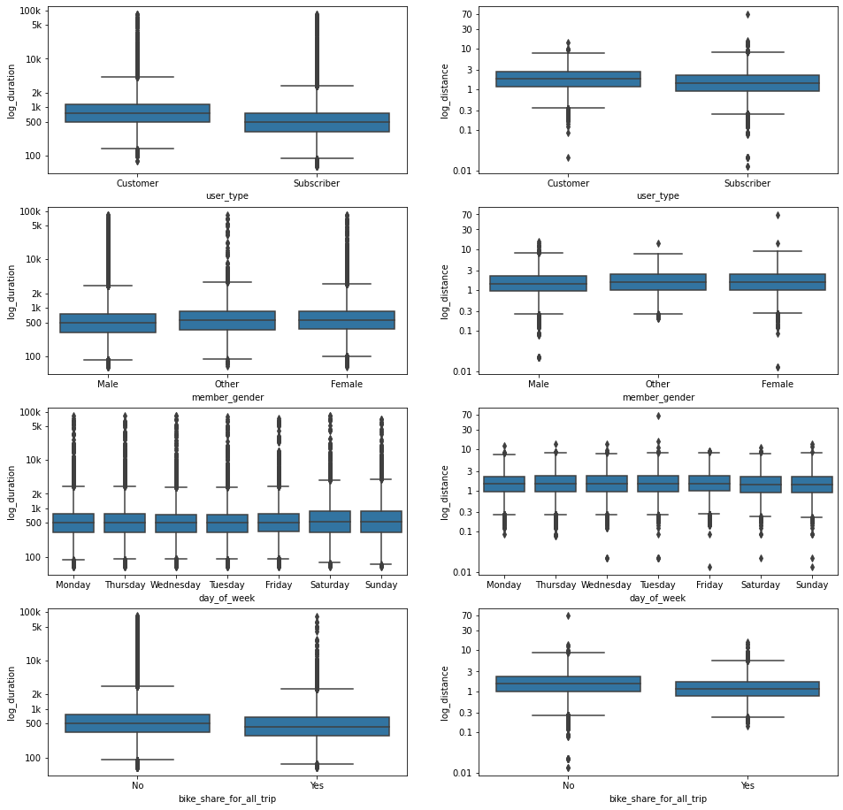

```python
# plot the categorical variables against duration and distance again, this time
# with full data and variable transforms
default_color = sb.color_palette()[0]
fig, ax = plt.subplots(nrows=4, ncols=2, figsize=(16, 16))
for i in range(len(categorical_vars)):
    var = categorical_vars[i]
    sb.boxplot(data=df_clean, x=var, y='log_duration', ax=ax[i, 0], color=default_color)
    ax[i, 0].set_yticks(log_trans(np.array([100, 500, 1e3, 2e3, 5e4, 1e4, 1e5])))
    ax[i,0].set_yticklabels([100, 500, '1k', '2k', '5k', '10k', '100k'])

    sb.boxplot(data=df_clean, x=var, y='log_distance', ax=ax[i, 1], color=default_color)
    ax[i, 1].set_yticks(log_trans(np.array([0.01, 0.1, 0.3, 1, 3, 10, 30, 70])))
    ax[i,1].set_yticklabels([0.01, 0.1, 0.3, 1, 3, 10, 30, 70]);
```

The plot of the full data using a box plot and variable transformations reveals much more than the earlier violin plots. This plot matrix of box plots with full data and features transformation is better than the one we saw earlier. in this plot we can see many things:

- The median of the duration for subscribers is less than customer although the difference in distance medians is very small so, here we can say that in general subscribers have small durations than customers for the smae trip distance
- The median of the duration for males is less than femals and others and this because males have a less distance median than Them.
- days of the week don't have any effect on the trip duration even if we saw slightly weekend trips duration median is bigger than the other days.
- Bike_share_for_all_trip has an opposite relation of user_type, for bike sharing, bikes not be shared have longer durations than bikes be shared for the same distance.

### Talk about some of the relationships you observed in this part of the investigation. How did the feature(s) of interest vary with other features in the dataset?

> Duration variable has a weak correlation with the distance varible when they are plotted on thier standard scales and they have a very strong positive correlation Approximately linear after plotting the two variables on the log-scale. The scatter plot suggested that Most of the trips' distances are between 0.3 & 10 Km and most of the trips' durations are less than 2k sec.

> There was also an interesting relationshipe between the duration and distance variables with the categorical variables. we know that increasing the distance makes the duration increase but we observe that subscribers can do long trips in short durations than customers and slightly males can do that than females and aslo not shared bikes can do long trips in short durations than shared bikes.

### Did you observe any interesting relationships between the other features (not the main feature(s) of interest)?

> There is a very small negative correlation between the member birth year and the distance and duration variables so it won't be explored further. There is a small interaction between the categorical variables, all riders that thier gender is "other" or they shared thier bikes are Subscribers.

## Multivariate Exploration

> The main thing I want to explore in this part of the analysis is how the Three (user_type, member_gender, day_of_week) categorical variables of trips play into the relationship between duration and distance.

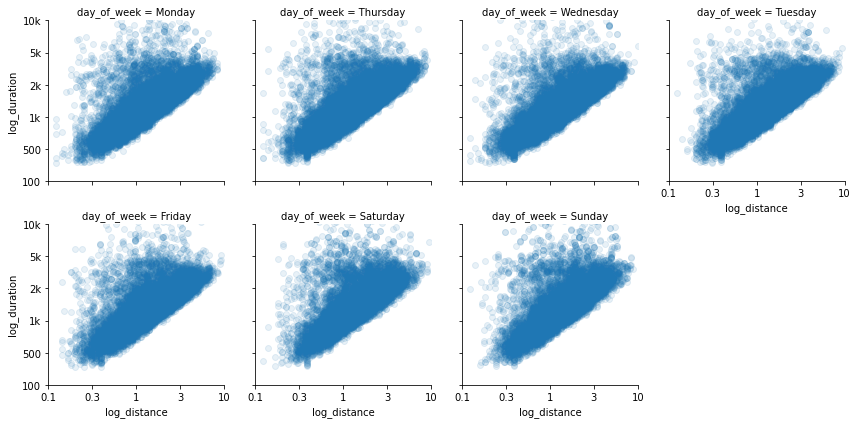

```python
# explor the relation of duration and distance for each day
g = sb.FacetGrid(data=df_clean, col='day_of_week', col_wrap=4, height=3,
                 xlim=[log_trans(0.1), log_trans(10)], ylim=[log_trans(60), log_trans(1e4)])
g.map(plt.scatter, 'log_distance', 'log_duration', alpha=1/10);
g.set_yticklabels([100, 500, 1e3, 2e3, 5e4, 1e4])
g.set_yticklabels([100, 500, '1k', '2k', '5k', '10k'])

g.set_xticklabels([0.1, 0.3, 1, 3, 10])
g.set_xticklabels([0.1, 0.3, 1, 3, 10]);
```

```python
def hist2dgrid(x, y, **kwargs):
    """ Quick hack for creating heat maps with seaborn's PairGrid. """
    palette = kwargs.pop('color')
    bins_x = np.arange(log_trans(.1), log_trans(10)+0.04, 0.04)
    bins_y = np.arange(log_trans(60), log_trans(1e4)+0.05, 0.05)
    plt.hist2d(x, y, bins = [bins_x, bins_y], cmap = palette, cmin = 5)
    plt.xticks(log_trans(np.array([0.1, 0.3, 1, 3, 10])), [0.1, 0.3, 1, 3, 10])
    plt.yticks(log_trans(np.array([100, 500, 1e3, 2e3, 5e4, 1e4])),
               [100, 500, '1k', '2k', '5k', '10k'])
```

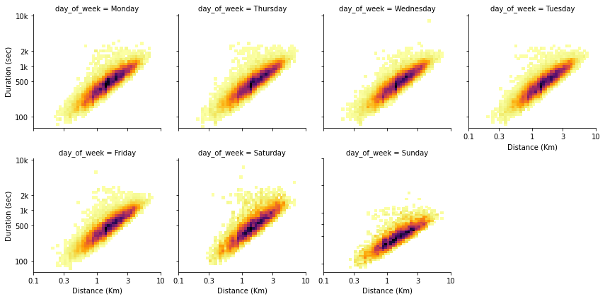

```python
# create faceted heat maps on days of the week variable
g = sb.FacetGrid(data = df_clean, col = 'day_of_week', col_wrap = 4, height = 3,
                 xlim=[log_trans(0.1), log_trans(10)], ylim=[log_trans(60), log_trans(1e4)])
g.map(hist2dgrid, 'log_distance', 'log_duration', color = 'inferno_r')
g.set_xlabels('Distance (Km)')
g.set_ylabels('Duration (sec)');
```

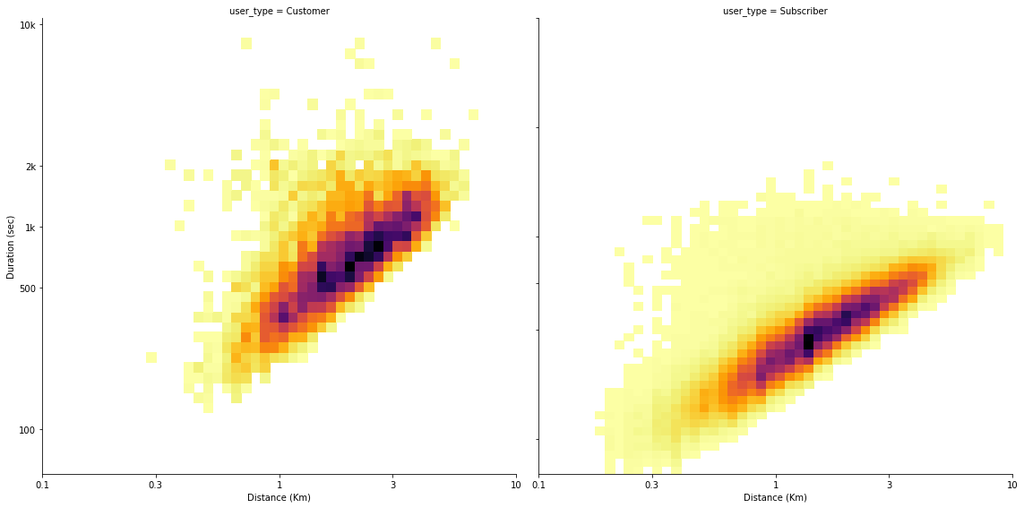

```python
# create faceted heat maps on days of the week variable
g = sb.FacetGrid(data = df_clean, col = 'user_type', col_wrap = 2, size = 8,
                 xlim=[log_trans(0.1), log_trans(10)], ylim=[log_trans(60), log_trans(1e4)])
g.map(hist2dgrid, 'log_distance', 'log_duration', color = 'inferno_r')
g.set_xlabels('Distance (Km)')
g.set_ylabels('Duration (sec)');
```

In this plot we can see, the cloud of points of subscribers moves towards the bottom right of the plot more than the cloud of point of customers and this movement means that subscribers do long trips in short durations than customers.

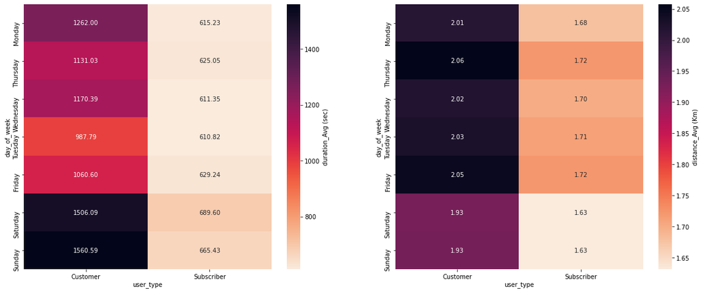

```python
# 'day_of_week', 'user_type' vs 'duration_sec'
plt.figure(figsize=(20, 8))

plt.subplot(1, 2, 1)
cat_mean = df_clean.groupby(['day_of_week', 'user_type']).mean()['duration_sec']
cat_mean = cat_mean.reset_index(name='duration_Avg')
cat_mean = cat_mean.pivot(index='day_of_week', columns='user_type', values='duration_Avg')
sb.heatmap(cat_mean, annot=True, fmt='.2f', cbar_kws={'label': 'duration_Avg (sec)'}, cmap='rocket_r');

# 'day_of_week', 'user_type' vs 'distance_Km'
plt.subplot(1, 2, 2)
cat_mean = df_clean.groupby(['day_of_week', 'user_type']).mean()['distance_Km']
cat_mean = cat_mean.reset_index(name='distance_Avg')
cat_mean = cat_mean.pivot(index='day_of_week', columns='user_type', values='distance_Avg')
sb.heatmap(cat_mean, annot=True, fmt='.2f', cbar_kws={'label': 'distance_Avg (Km)'}, cmap='rocket_r');
```

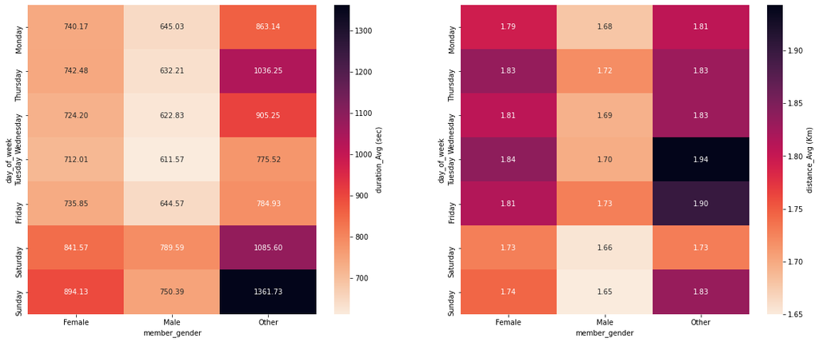

```python
# 'day_of_week', 'member_gender' vs 'duration_sec'
plt.figure(figsize=(20, 8))

plt.subplot(1, 2, 1)
cat_mean = df_clean.groupby(['day_of_week', 'member_gender']).mean()['duration_sec']
cat_mean = cat_mean.reset_index(name='duration_Avg')
cat_mean = cat_mean.pivot(index='day_of_week', columns='member_gender', values='duration_Avg')
sb.heatmap(cat_mean, annot=True, fmt='.2f', cbar_kws={'label': 'duration_Avg (sec)'}, cmap='rocket_r');

# 'day_of_week', 'member_gender' vs 'distance_Km'
plt.subplot(1, 2, 2)
cat_mean = df_clean.groupby(['day_of_week', 'member_gender']).mean()['distance_Km']
cat_mean = cat_mean.reset_index(name='distance_Avg')
cat_mean = cat_mean.pivot(index='day_of_week', columns='member_gender', values='distance_Avg')
sb.heatmap(cat_mean, annot=True, fmt='.2f', cbar_kws={'label': 'distance_Avg (Km)'}, cmap='rocket_r');
```

Then, after all it is clear now that these categorical variables have a strong effect on the duration of the trip regardless its distance.

### Talk about some of the relationships you observed in this part of the investigation. Were there features that strengthened each other in terms of looking at your feature(s) of interest?

> I extended my investigation of duration against distance in this section by looking at the impact of the categorical features. The multivariate exploration here showed that there indeed is a positive effect of days and gender of the rider and his type on the duration of the trip, we saw in the plots that riders who are subscribers and mals have the lowest average trip duration in general and a day like "Tuesday" has the lowest avarge durations than other days althought "Saturday" has the lowest avarage distance.

### Were there any interesting or surprising interactions between features?

> by looking back to the plots, it doesn't seem like there's a systematic interaction effect between the three categorical features.